# RESULTS DOC

## TPC Subgroups

### Gemcitabine/Carboplatin

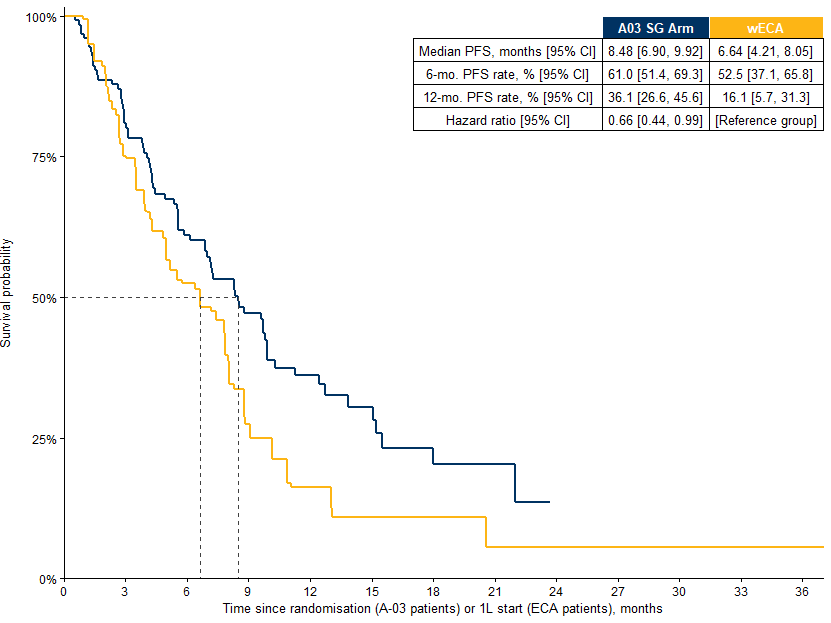

### ASCENT-03 SG Arm vs ASCENT-03 Control Arm vs Weighted ECA

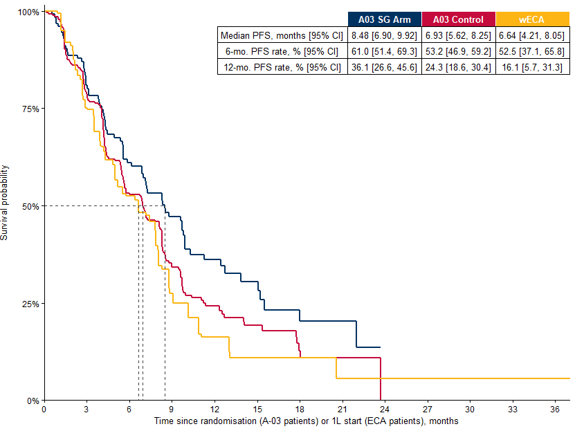

### nab-Paclitaxel

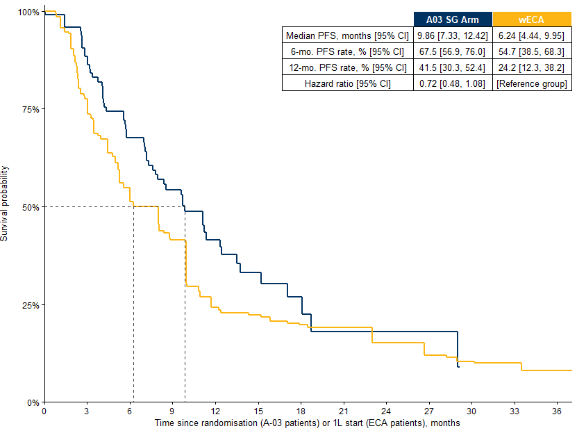

### ASCENT-03 SG Arm vs ASCENT-03 Control Arm vs Weighted ECA

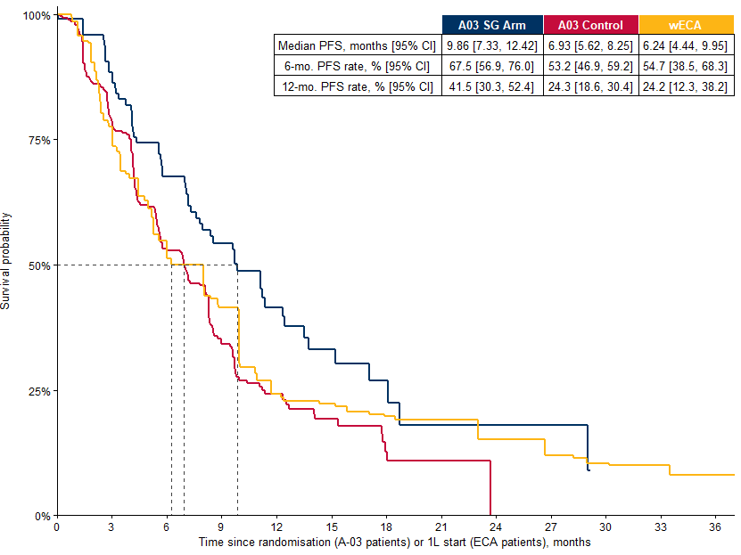

### Paclitaxel

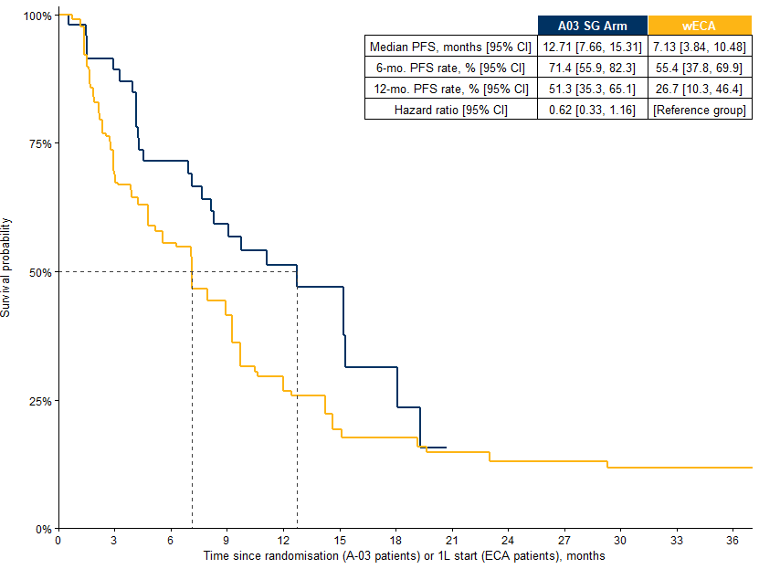

### ASCENT-03 SG Arm vs ASCENT-03 Control Arm vs Weighted ECA

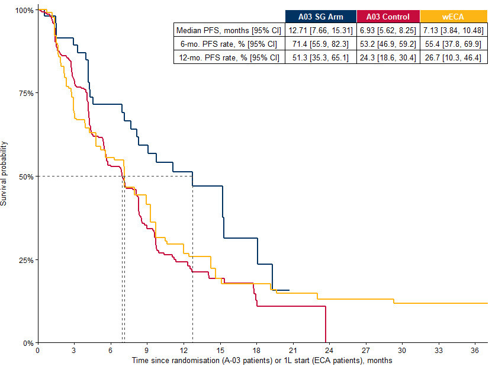

# WEIGHTS DIAGNOSTICS

- Trimmed-weight versions are not presented here, but are stored in the DARS study folder
- Diagnostics plots are stored in the DARS study folder for each imputation in Approaches E and F

## Approach A

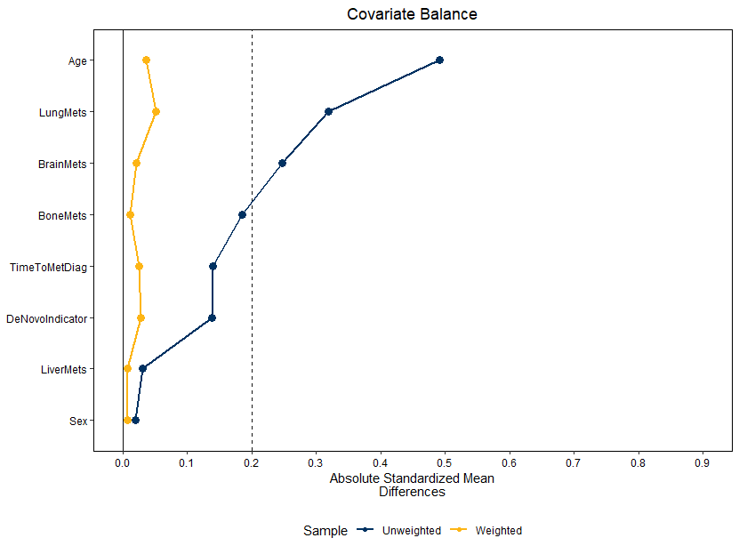

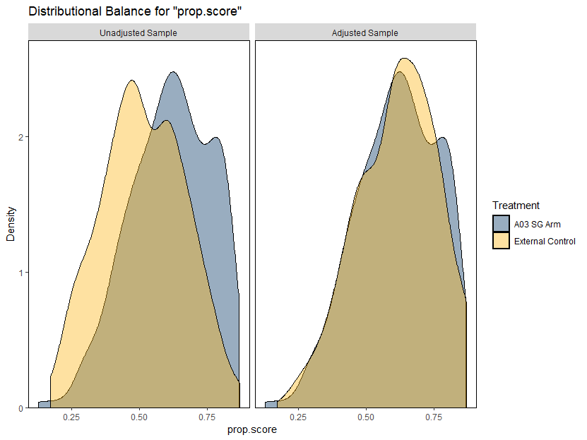

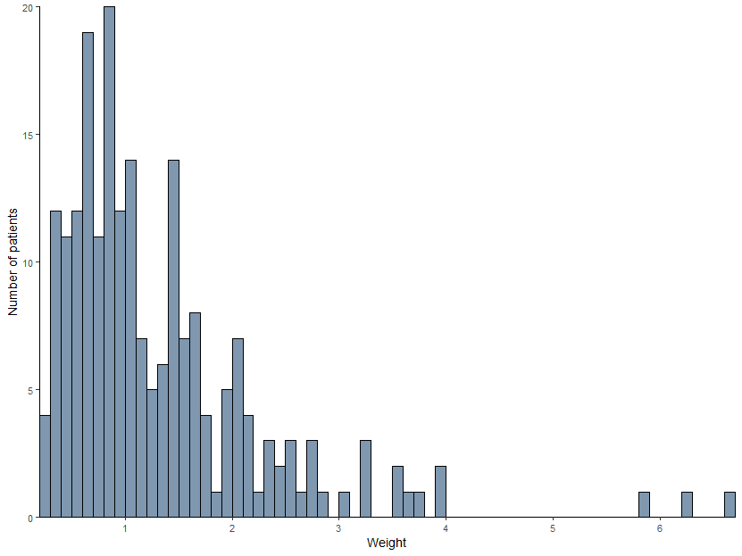

## Approach B

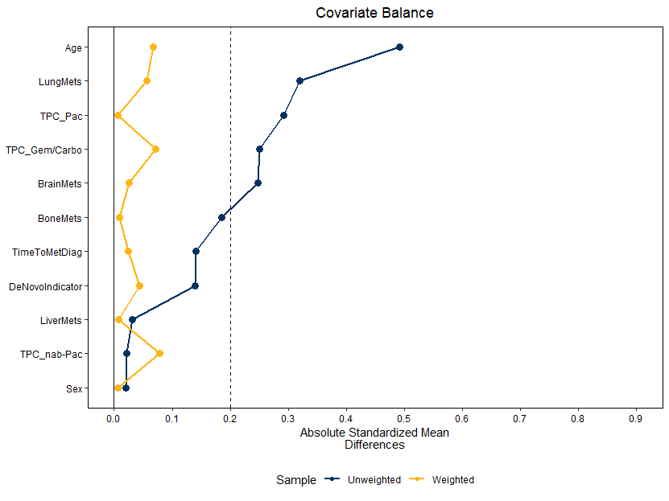

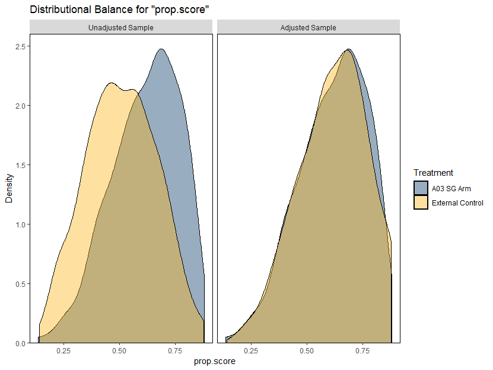

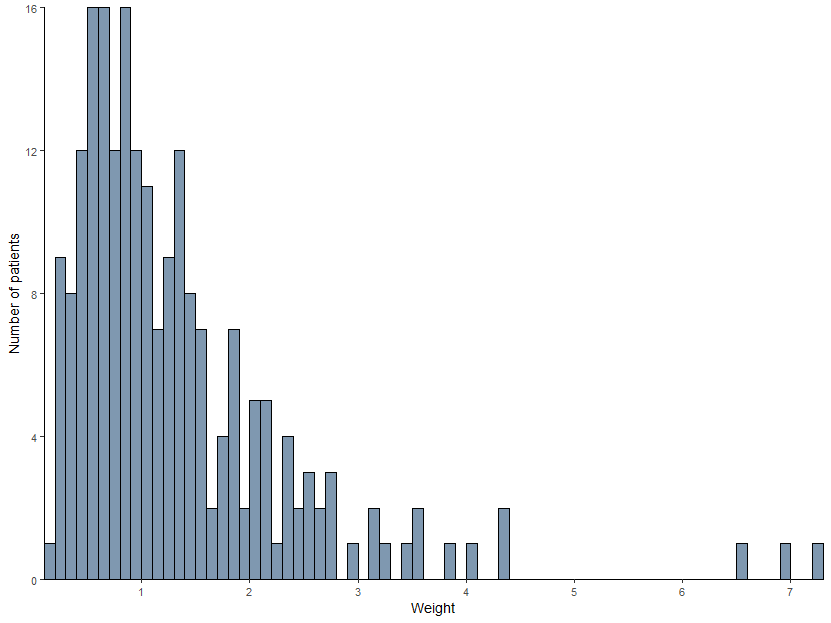

## Approach C

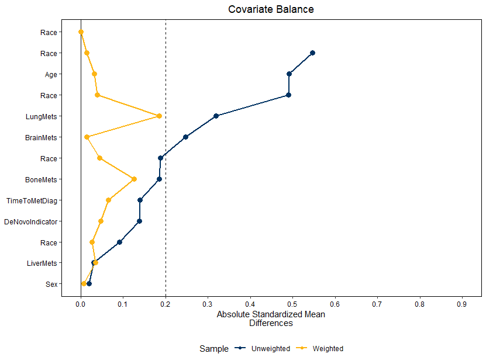

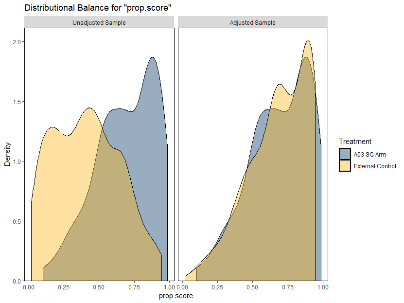

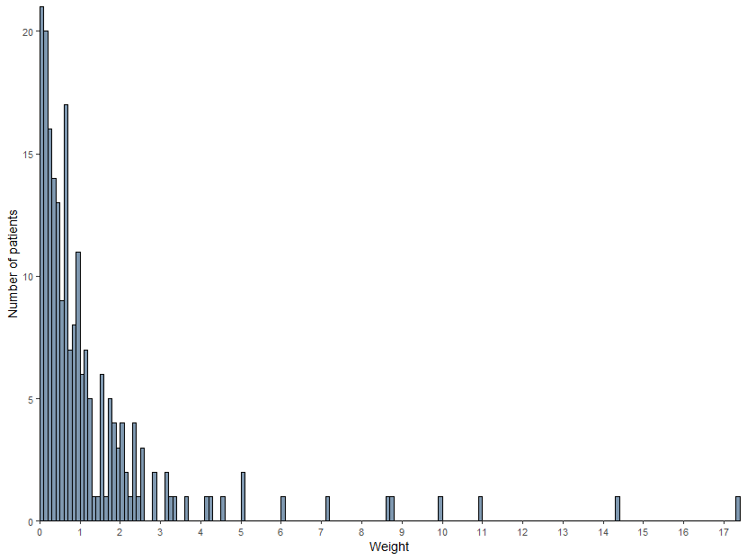

## Approach D

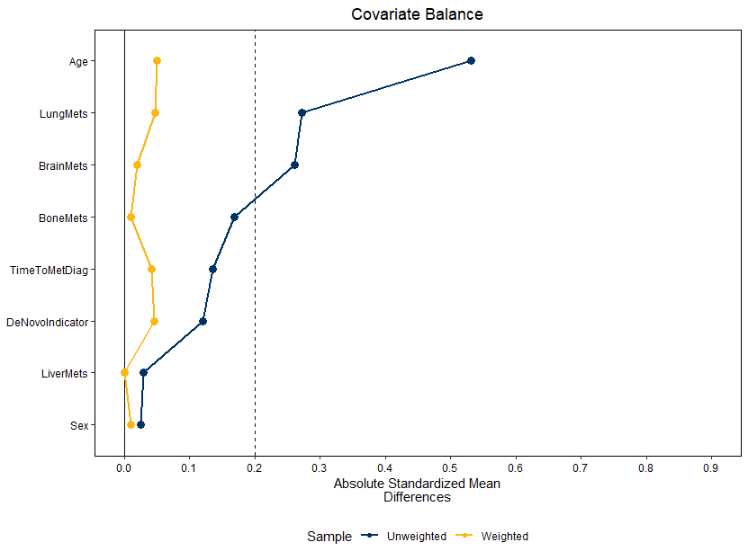

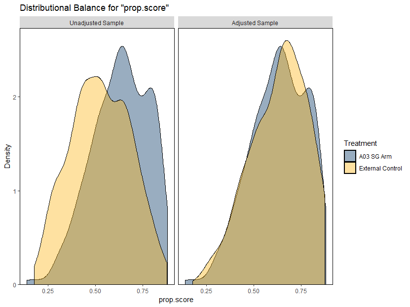

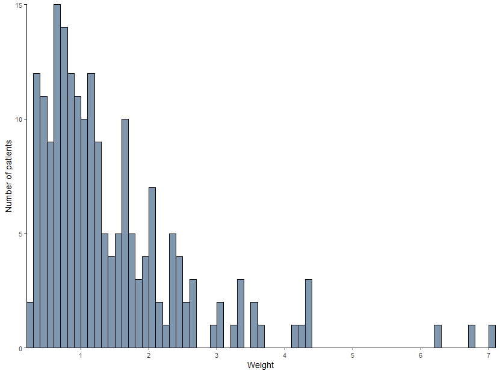

## Approach E

- Plots are stored per imputation in the DARS study folder

| **Imputation** | **Weights diagnostics** **Range** | **Weights diagnostics** **RW N Pts** | **Weights diagnostics** **ESS** | **Weights diagnostics** **Top Five** |
| --- | --- | --- | --- | --- |
| 1 | 0.22-7.0 | 196 | 125.0 | 4.5, 4.5, 5.4, 6.1, 7.0 |
| 2 | 0.20-6.8 | 196 | 128.1 | 4.1, 4.4, 5.3, 5.9, 6.8 |
| 3 | 0.19-7.1 | 199 | 128.3 | 4.1, 4.4, 5.4, 6.0, 7.1 |
| 4 | 0.21-6.4 | 203 | 136.3 | 3.8, 4.0, 4.8, 5.3, 6.4 |
| 5 | 0.24-7.0 | 194 | 129.5 | 4.1, 4.5, 5.0, 5.6, 7.0 |
| 6 | 0.19-7.3 | 191 | 122.1 | 4.8, 4.9, 5.1, 5.3, 7.3 |
| 7 | 0.20-6.8 | 198 | 129.7 | 4.0, 4.2, 5.2, 5.8, 6.8 |
| 8 | 0.21-6.6 | 198 | 133.2 | 3.9, 4.4, 5.0, 5.5, 6.6 |
| 9 | 0.20-6.9 | 200 | 131.2 | 4.4, 4.4, 4.7, 5.3, 6.9 |
| 10 | 0.18-7.1 | 202 | 131.7 | 4.4, 4.5, 4.9, 5.4, 7.1 |
| 11 | 0.21-6.8 | 193 | 128.6 | 4.2, 4.4, 5.1, 5.6, 6.8 |
| 12 | 0.24-7.0 | 192 | 126.1 | 4.1, 4.7, 5.5, 6.2, 7.0 |
| 13 | 0.20-8.4 | 192 | 116.3 | 4.9, 4.9, 5.6, 6.3, 8.4 |
| 14 | 0.19-7.5 | 198 | 125.6 | 4.4, 4.5, 5.4, 6.1, 7.5 |
| 15 | 0.22-7.0 | 193 | 126.0 | 4.3, 4.5, 5.3, 5.9, 7.0 |
| 16 | 0.20-7.3 | 201 | 128.0 | 4.3, 4.7, 4.8, 5.2, 7.3 |
| 17 | 0.21-6.3 | 197 | 133.1 | 4.2, 4.5, 4.8, 5.3, 6.3 |
| 18 | 0.19-7.0 | 196 | 126.9 | 4.3, 4.9, 5.2, 5.8, 7.0 |
| 19 | 0.20-7.0 | 198 | 126.3 | 4.2, 4.8, 5.4, 6.1, 7.0 |
| 20 | 0.21-7.0 | 202 | 130.0 | 4.3, 4.4, 5.0, 5.6, 7.0 |
| 21 | 0.21-6.9 | 193 | 128.8 | 4.2, 4.5, 4.8, 5.3, 6.9 |
| 22 | 0.22-6.8 | 197 | 132.6 | 4.0, 4.5, 4.6, 5.1, 6.8 |
| 23 | 0.20-6.8 | 196 | 127.5 | 4.2, 4.5, 5.5, 6.2, 6.8 |
| 24 | 0.21-7.2 | 188 | 121.6 | 4.5, 5.0, 5.6, 6.2, 7.2 |
| 25 | 0.23-7.1 | 197 | 125.1 | 4.2, 4.5, 5.8, 6.6, 7.1 |

## Approach F

- Plots are stored per imputation in the DARS study folder

| **Imputation** | **Weights diagnostics** **Range** | **Weights diagnostics** **RW N Pts** | **Weights diagnostics** **ESS** | **Weights diagnostics** **Top Five** |
| --- | --- | --- | --- | --- |
| 1 | 0.22-7.0 | 196 | 125.0 | 4.5, 4.5, 5.4, 6.1, 7.0 |
| 2 | 0.20-6.8 | 196 | 128.1 | 4.1, 4.4, 5.3, 5.9, 6.8 |
| 3 | 0.19-7.1 | 199 | 128.3 | 4.1, 4.4, 5.4, 6.0, 7.1 |
| 4 | 0.21-6.4 | 203 | 136.3 | 3.8, 4.0, 4.8, 5.3, 6.4 |
| 5 | 0.24-7.0 | 194 | 129.5 | 4.1, 4.5, 5.0, 5.6, 7.0 |
| 6 | 0.19-7.3 | 191 | 122.1 | 4.8, 4.9, 5.1, 5.3, 7.3 |
| 7 | 0.20-6.8 | 198 | 129.7 | 4.0, 4.2, 5.2, 5.8, 6.8 |
| 8 | 0.21-6.6 | 198 | 133.2 | 3.9, 4.4, 5.0, 5.5, 6.6 |
| 9 | 0.20-6.9 | 200 | 131.2 | 4.4, 4.4, 4.7, 5.3, 6.9 |
| 10 | 0.18-7.1 | 202 | 131.7 | 4.4, 4.5, 4.9, 5.4, 7.1 |
| 11 | 0.21-6.8 | 193 | 128.6 | 4.2, 4.4, 5.1, 5.6, 6.8 |
| 12 | 0.24-7.0 | 192 | 126.1 | 4.1, 4.7, 5.5, 6.2, 7.0 |
| 13 | 0.20-8.4 | 192 | 116.3 | 4.9, 4.9, 5.6, 6.3, 8.4 |
| 14 | 0.19-7.5 | 198 | 125.6 | 4.4, 4.5, 5.4, 6.1, 7.5 |
| 15 | 0.22-7.0 | 193 | 126.0 | 4.3, 4.5, 5.3, 5.9, 7.0 |
| 16 | 0.20-7.3 | 201 | 128.0 | 4.3, 4.7, 4.8, 5.2, 7.3 |
| 17 | 0.21-6.3 | 197 | 133.1 | 4.2, 4.5, 4.8, 5.3, 6.3 |
| 18 | 0.19-7.0 | 196 | 126.9 | 4.3, 4.9, 5.2, 5.8, 7.0 |
| 19 | 0.20-7.0 | 198 | 126.3 | 4.2, 4.8, 5.4, 6.1, 7.0 |
| 20 | 0.21-7.0 | 202 | 130.0 | 4.3, 4.4, 5.0, 5.6, 7.0 |
| 21 | 0.21-6.9 | 193 | 128.8 | 4.2, 4.5, 4.8, 5.3, 6.9 |
| 22 | 0.22-6.8 | 197 | 132.6 | 4.0, 4.5, 4.6, 5.1, 6.8 |
| 23 | 0.20-6.8 | 196 | 127.5 | 4.2, 4.5, 5.5, 6.2, 6.8 |
| 24 | 0.21-7.2 | 188 | 121.6 | 4.5, 5.0, 5.6, 6.2, 7.2 |
| 25 | 0.23-7.1 | 197 | 125.1 | 4.2, 4.5, 5.8, 6.6, 7.1 |

## TPC Subgroups

### Gemcitabine/Carboplatin

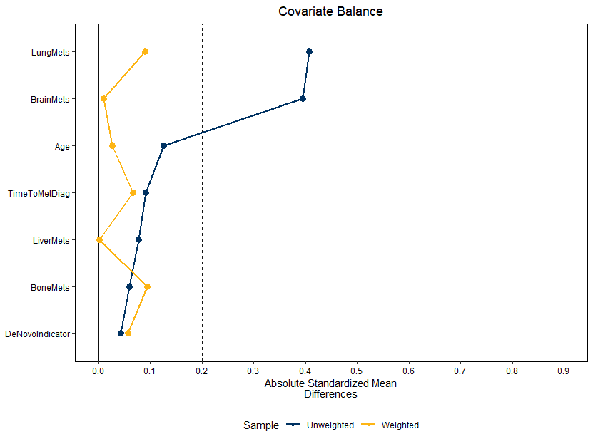

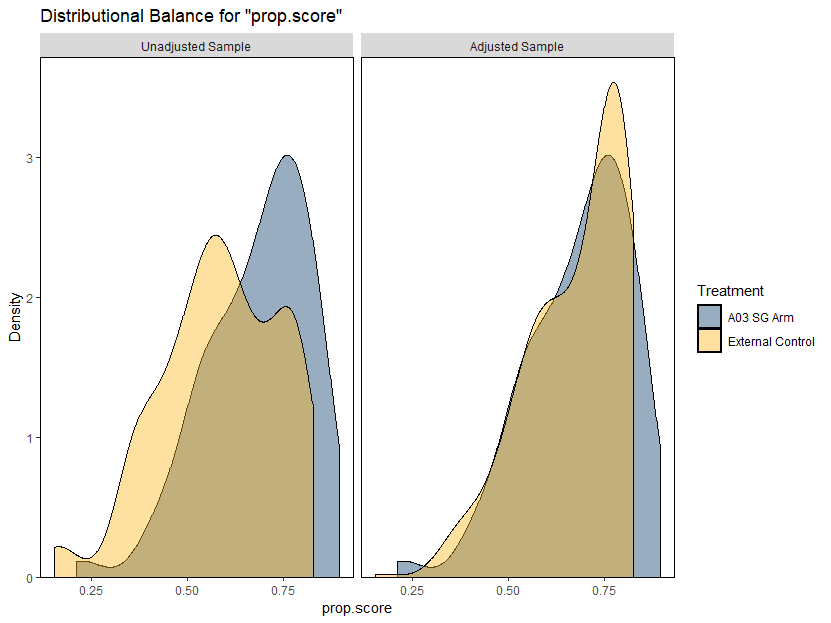

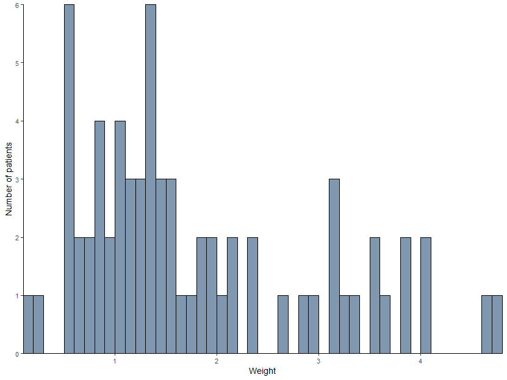

### nab-Paclitaxel

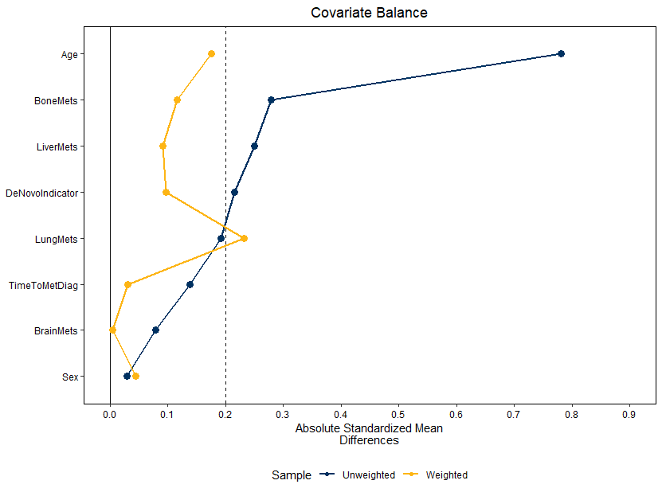

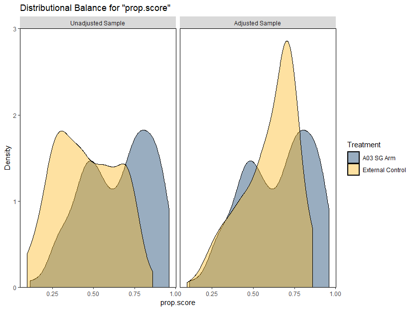

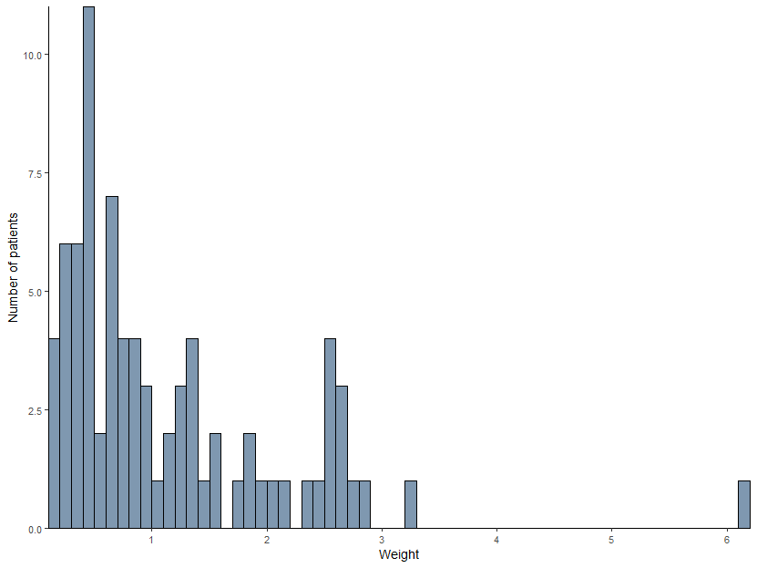

### Paclitaxel

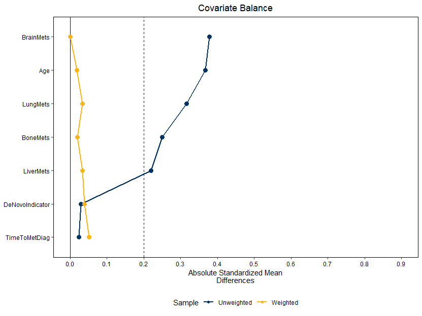

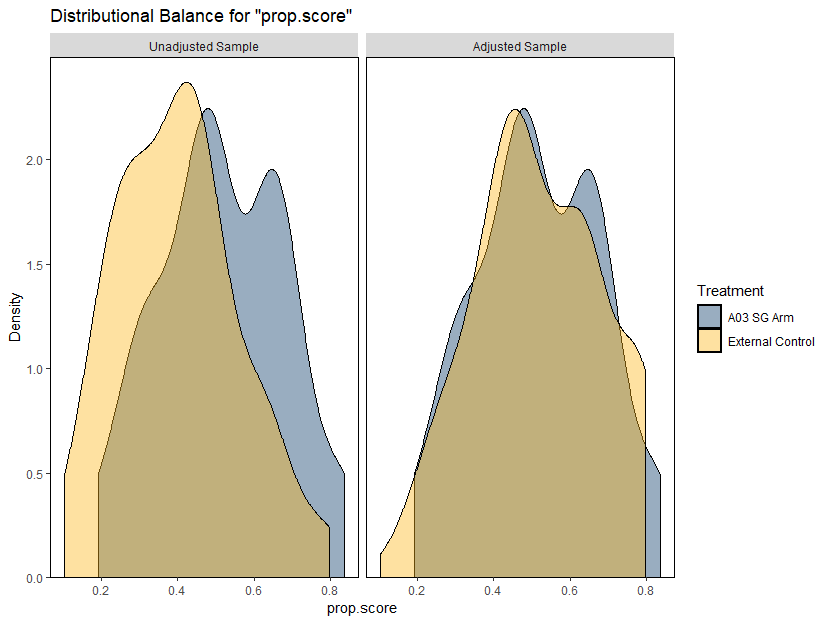

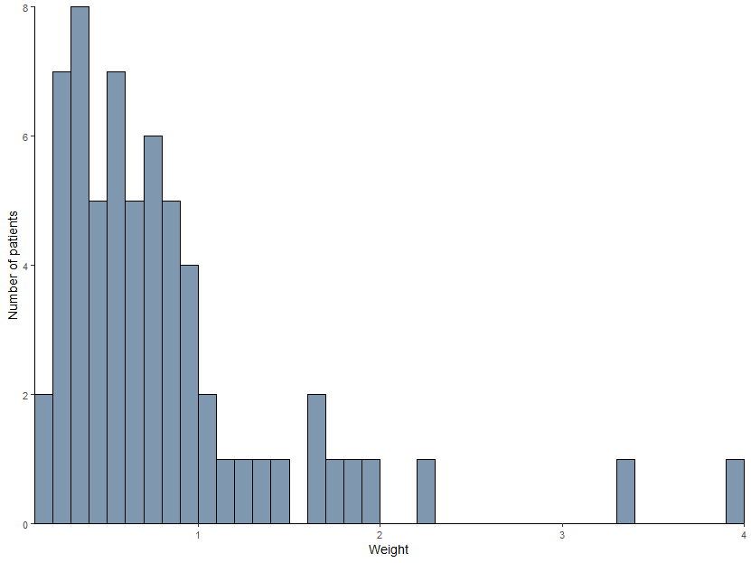